# Lab 5: Inference for Numerical Data

### North Carolina births

In 2004, the state of North Carolina released a large data set containing information on births recorded in this state. This data set is useful to researchers studying the relation between habits and practices of expectant mothers and the birth of their children. We will work with a random sample of observations from this data set.

### Exploratory analysis

Load the `nc` data set into our workspace.

```r
if(!file.exists('nc.RData')) {
    download.file("http://www.openintro.org/stat/data/nc.RData", destfile = "nc.RData")
}
load("nc.RData")
set.seed(2112) # This will ensure that the sample will return the same result each time.
```

We have observations on 13 different variables, some categorical and some numerical. The meaning of each variable is as follows.

- `fage` - father’s age in years.
- `mage` - mother’s age in years. mature maturity status of mother.
- `weeks` - length of pregnancy in weeks.
- `premie` - whether the birth was classified as premature (premie) or full-term. visits number of hospital visits during pregnancy.
- `marital` - whether mother is married or not married at birth. gained weight gained by mother during pregnancy in pounds. weight weight of the baby at birth in pounds.
- `lowbirthweight` - whether baby was classified as low birthweight (low) or not (not low). gender gender of the baby, female or male.
- `habit` - status of the mother as a nonsmoker or a smoker. whitemom ￼ whether mom is white or not white.

**Exercise 1** What are the cases in this data set? How many cases are there in our sample?

```r
nrow(nc)
```

```
## [1] 1000
```

Each record represents a birth in North Carolina in 2004. There are 1000 cases.

As a first step in the analysis, we should consider summaries of the data. This can be done using the `summary` command:

```r
summary(nc)
```

```
##       fage           mage            mature        weeks
##  Min.   :14.0   Min.   :13   mature mom :133   Min.   :20.0
##  1st Qu.:25.0   1st Qu.:22   younger mom:867   1st Qu.:37.0
##  Median :30.0   Median :27                     Median :39.0
##  Mean   :30.3   Mean   :27                     Mean   :38.3
##  3rd Qu.:35.0   3rd Qu.:32                     3rd Qu.:40.0
##  Max.   :55.0   Max.   :50                     Max.   :45.0
##  NA's   :171                                   NA's   :2
##        premie        visits            marital        gained
##  full term:846   Min.   : 0.0   married    :386   Min.   : 0.0
##  premie   :152   1st Qu.:10.0   not married:613   1st Qu.:20.0
##  NA's     :  2   Median :12.0   NA's       :  1   Median :30.0
##                  Mean   :12.1                     Mean   :30.3
##                  3rd Qu.:15.0                     3rd Qu.:38.0
##                  Max.   :30.0                     Max.   :85.0
##                  NA's   :9                        NA's   :27
##      weight      lowbirthweight    gender          habit
##  Min.   : 1.00   low    :111    female:503   nonsmoker:873
##  1st Qu.: 6.38   not low:889    male  :497   smoker   :126
##  Median : 7.31                               NA's     :  1
##  Mean   : 7.10
##  3rd Qu.: 8.06
##  Max.   :11.75
##
##       whitemom
##  not white:284
##  white    :714
##  NA's     :  2
##
##
##
##
```

As you review the variable summaries, consider which variables are categorical and which are numerical. For numerical variables, are there outliers? If you aren’t sure or want to take a closer look at the data, make a graph.

Consider the possible relationship between a mother’s smoking habit and the weight of her baby. Plotting the data is a useful first step because it helps us quickly visualize trends, identify strong associations, and develop research questions.

**Exercise 2** Make a side-by-side boxplot of `habit` and `weight`. What does the plot highlight about the relationship between these two variables?

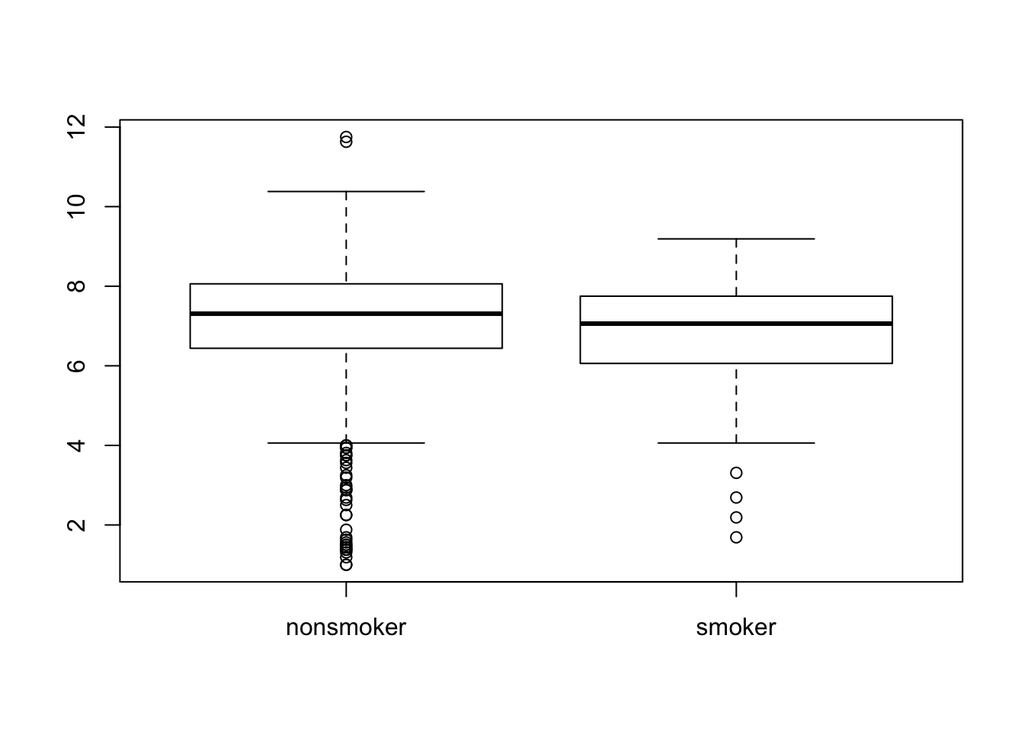

```r
boxplot(weight ~ habit, data=nc)
```

It appears that the birth weight for mothers who smoked is lower than non-smokers on average.

The box plots show how the medians of the two distributions compare, but we can also compare the means of the distributions using the following function to split the `weight` variable into the `habit` groups, then take the mean of each using the `mean` function.

```r
by(nc$weight, nc$habit, mean)
```

```
## nc$habit: nonsmoker
## [1] 7.144
## --------------------------------------------------------
## nc$habit: smoker
## [1] 6.829
```

There is an observed difference, but is this difference statistically significant? In order to answer this question we will conduct a hypothesis test.

### Inference

**Exercise 3** Check if the conditions necessary for inference are satisfied. Note that you will need to obtain sample sizes to check the conditions. You can compute the group size using the same by command above but replacing mean with length.

```r
by(nc$weight, nc$habit, length)
```

```
## nc$habit: nonsmoker
## [1] 873
## --------------------------------------------------------
## nc$habit: smoker
## [1] 126
```

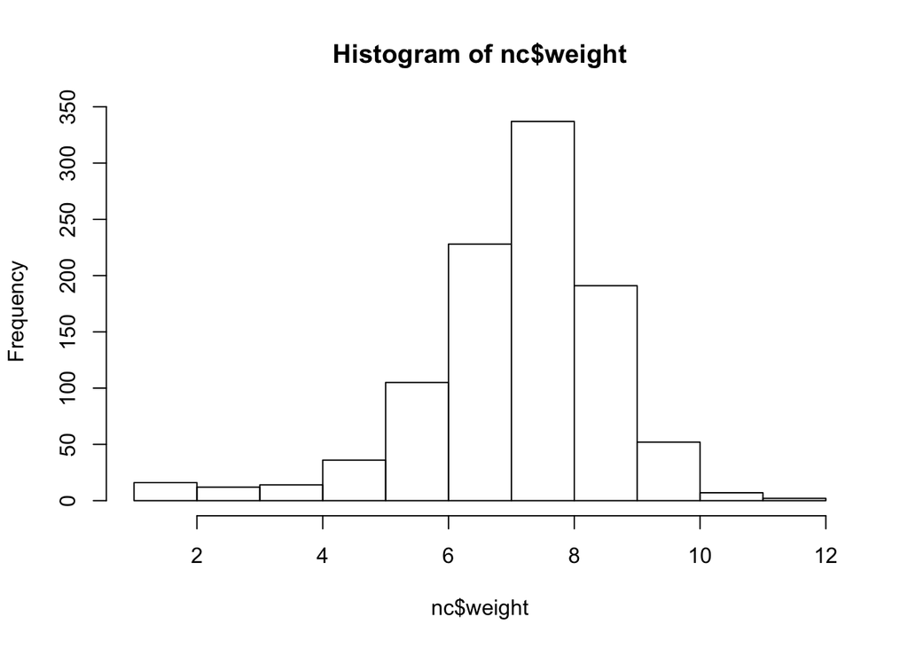

```r
hist(nc$weight)
```

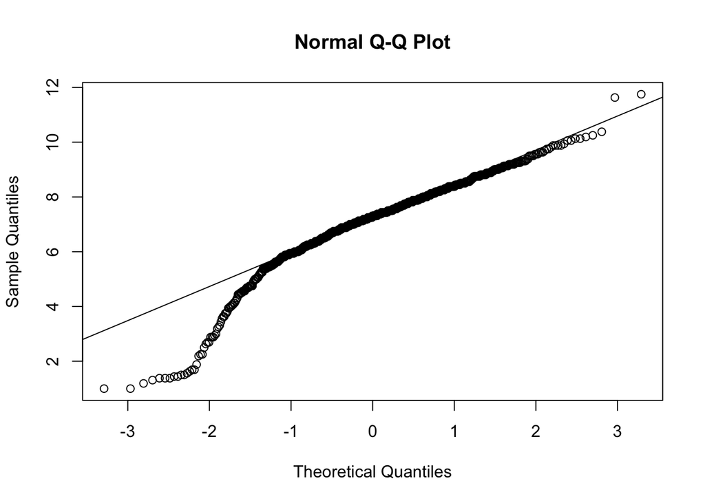

```r
qqnorm(nc$weight)
qqline(nc$weight)
```

Conditions: 1. Independence within groups. 2. Independence between groups. 3. Sample size (need at least 30). 4. No substantial skewness. There could be some outliers on the low end, otherwise looks fairly symmetric.

**Exercise 4** Write the hypotheses for testing if the average weights of babies born to smoking and non-smoking mothers are different.

$H_0: \mu_{smoking} = \mu_{not smoking}$ $H_A: \mu_{smoking} \neq \mu_{not smoking}$

Next, we introduce a new function, inference, that we will use for conducting hypothesis tests and constructing confidence intervals.

```r
inference(y = nc$weight, x = nc$habit, est = "mean", type = "ht", null = 0,
          alternative = "twosided", method = "theoretical")
```

```
## Response variable: numerical, Explanatory variable: categorical
## Difference between two means
## Summary statistics:
## n_nonsmoker = 873, mean_nonsmoker = 7.144, sd_nonsmoker = 1.519
## n_smoker = 126, mean_smoker = 6.829, sd_smoker = 1.386
```

```
## Observed difference between means (nonsmoker-smoker) = 0.3155
##
## H0: mu_nonsmoker - mu_smoker = 0
## HA: mu_nonsmoker - mu_smoker != 0
## Standard error = 0.134
## Test statistic: Z =  2.359
## p-value =  0.0184
```

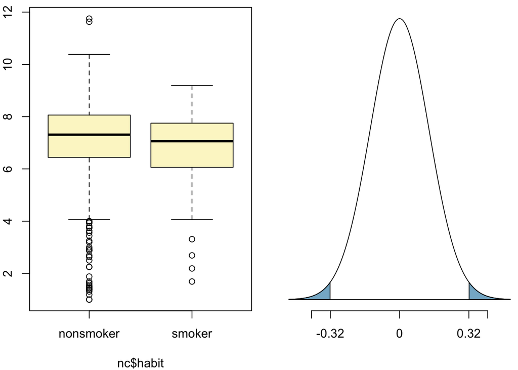

Let’s pause for a moment to go through the arguments of this custom function.

- The first argument is `y`, which is the response variable that we are interested in: `nc$weight`.
- The second argument is the explanatory variable, `x`, which is the variable that splits the data into two groups, smokers and non-smokers: `nc$habit`.
- The third argument, `est`, is the parameter we’re interested in: “mean” (other options are “median”, or “proportion”.)
- Next we decide on the `type` of inference we want: a hypothesis test (ht) or a confidence interval (“ci”).
- When performing a hypothesis test, we also need to supply the `null` value, which in this case is 0, since the null hypothesis sets the two population means equal to each other.
- The `alternative` hypothesis can be “less”, “greater”, or “twosided”.
- Lastly, the `method` of inference can be “theoretical” or “simulation” based.

**Exercise 5** Change the `type` argument to “ci” to construct and record a confidence interval for the difference between the weights of babies born to smoking and non-smoking mothers.

```r
inference(y = nc$weight, x = nc$habit, est = "mean", type = "ci", null = 0,
          alternative = "twosided", method = "theoretical")
```

```
## Response variable: numerical, Explanatory variable: categorical
## Difference between two means
## Summary statistics:
## n_nonsmoker = 873, mean_nonsmoker = 7.144, sd_nonsmoker = 1.519
## n_smoker = 126, mean_smoker = 6.829, sd_smoker = 1.386
```

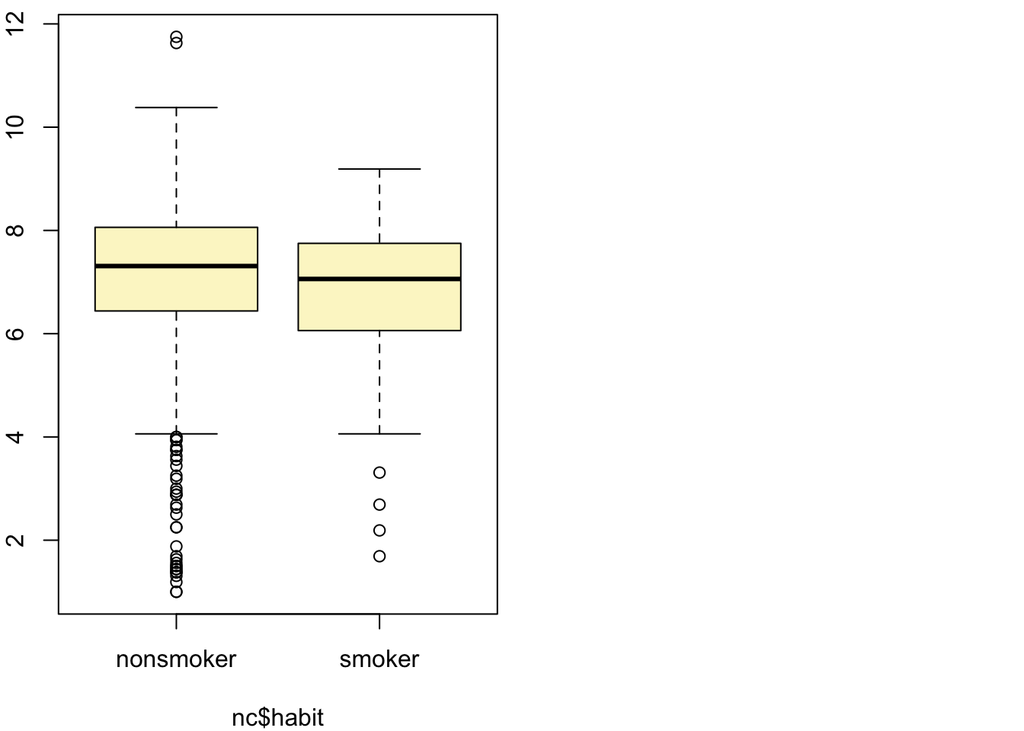

```
## Observed difference between means (nonsmoker-smoker) = 0.3155
##
## Standard error = 0.1338
## 95 % Confidence interval = ( 0.0534 , 0.5777 )
```

By default the function reports an interval for ($\mu_{nonsmoker} − \mu_{smoker}$). We can easily change this order by using the `order` argument:

```r
inference(y = nc$weight, x = nc$habit, est = "mean", type = "ci", null = 0,
          alternative = "twosided", method = "theoretical",
          order = c("smoker","nonsmoker"))
```

```
## Response variable: numerical, Explanatory variable: categorical
## Difference between two means
## Summary statistics:
## n_smoker = 126, mean_smoker = 6.829, sd_smoker = 1.386
## n_nonsmoker = 873, mean_nonsmoker = 7.144, sd_nonsmoker = 1.519
```

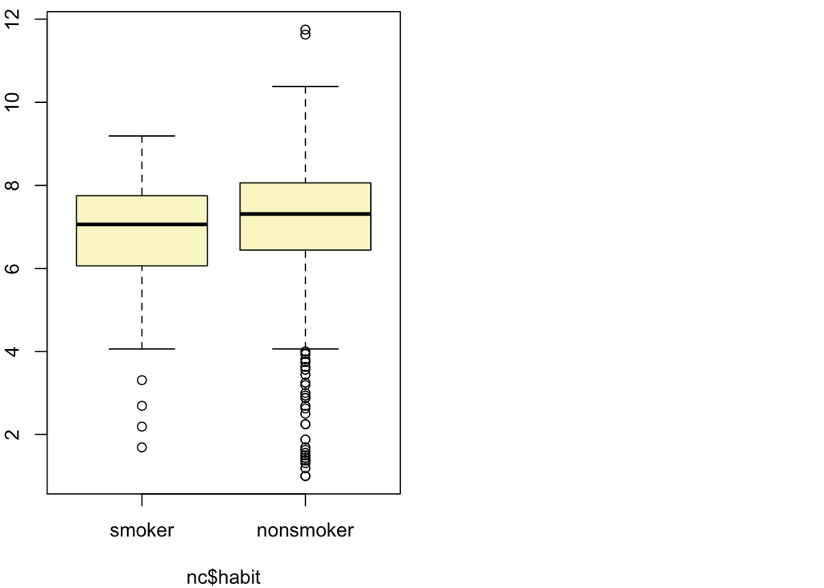

```
## Observed difference between means (smoker-nonsmoker) = -0.3155
##
## Standard error = 0.1338
## 95 % Confidence interval = ( -0.5777 , -0.0534 )
```

### On your own

#### 1. Calculate a 95% confidence interval for the average length of pregnancies (weeks) and interpret it in context. Note that since you’re doing inference on a single population parameter, there is no explanatory variable, so you can omit the x variable from the function.

```r
inference(y = nc$weeks, est = "mean", type = "ci", null = 0,
          alternative = "twosided", method = "theoretical")
```

```
## Single mean
## Summary statistics:
```

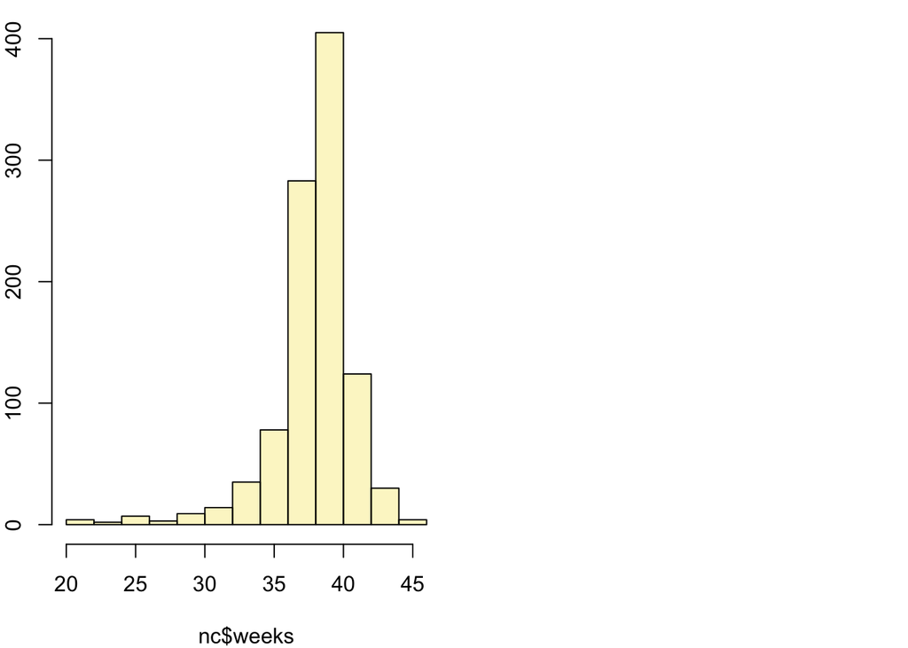

```
## mean = 38.3347 ;  sd = 2.9316 ;  n = 998
## Standard error = 0.0928
## 95 % Confidence interval = ( 38.1528 , 38.5165 )
```

We are 95% confident that the true mean length of weeks for giving birth is between 38.2 and 38.5 weeks.

#### 2. Calculate a new confidence interval for the same parameter at the 90% confidence level. You can change the confidence level by adding a new argument to the function: `conflevel=0.90`.

```r
inference(y = nc$weeks, est = "mean", type = "ci", null = 0,
          alternative = "twosided", method = "theoretical", conflevel=0.90)
```

```
## Single mean
## Summary statistics:
```

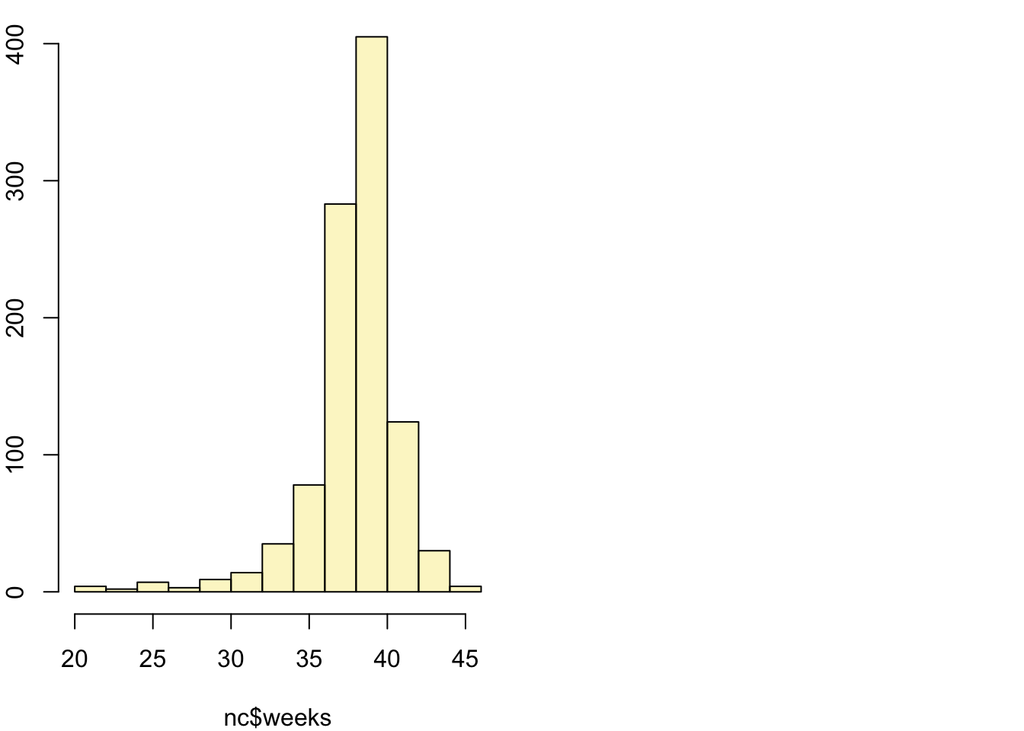

```
## mean = 38.3347 ;  sd = 2.9316 ;  n = 998
## Standard error = 0.0928
## 90 % Confidence interval = ( 38.182 , 38.4873 )
```

#### 3. Conduct a hypothesis test evaluating whether the average weight gained by younger mothers is different than the average weight gained by mature mothers.

```r
inference(y = nc$gained, x = nc$mature, est = "mean", type = "ci", null=0,
          alternative = "twosided", method = "theoretical", conflevel=0.95)
```

```
## Response variable: numerical, Explanatory variable: categorical
## Difference between two means
## Summary statistics:
## n_mature mom = 129, mean_mature mom = 28.79, sd_mature mom = 13.48
## n_younger mom = 844, mean_younger mom = 30.56, sd_younger mom = 14.35
```

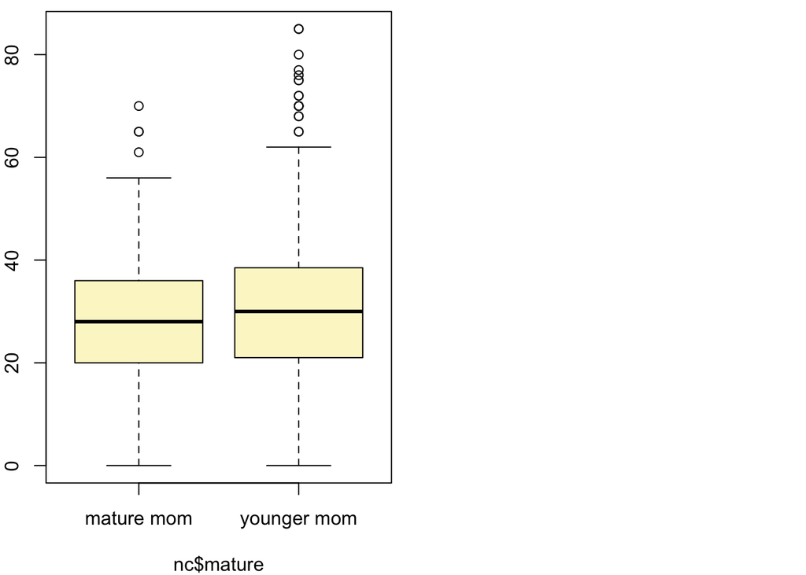

```
## Observed difference between means (mature mom-younger mom) = -1.77
##
## Standard error = 1.286
## 95 % Confidence interval = ( -4.2896 , 0.7502 )
```

There is not a statistically significant difference in weight gained by mature and non-mature mothers.

#### 4. Now, a non-inference task: Determine the age cutoff for younger and mature mothers. Use a method of your choice, and explain how your method works.

```r
by(nc$mage, nc$mature, FUN=range)
```

```
## nc$mature: mature mom
## [1] 35 50
## --------------------------------------------------------
## nc$mature: younger mom
## [1] 13 34
```

The cutoff for younger mothers is 34 and less and 35 and above for mature mothers. Here, we look at the maximum of `mage` for younger mothers and the minimum of `mage` for mature mothers.

#### 5. Pick a pair of numerical and categorical variables and come up with a research question evaluating the relationship between these variables. Formulate the question in a way that it can be answered using a hypothesis test and/or a confidence interval. Answer your question using the inference function, report the statistical results, and also provide an explanation in plain language.

$H_0: \mu_{Age for Married} = \mu_{Age for Not Married}$ $H_A: \mu_{Age for Married} \neq \mu_{Age for Not Married}$

```r
x <- nc$marital # Can be any qualitative variable
y <- nc$mage    # Can be any quantitative variable
inference(y = y, x = x, est = "mean", type = "ci", null=0,
          alternative = "twosided", method = "theoretical", conflevel=0.95)
```

```
## Response variable: numerical, Explanatory variable: categorical
## Difference between two means
## Summary statistics:
## n_married = 386, mean_married = 23.56, sd_married = 5.658
## n_not married = 613, mean_not married = 29.14, sd_not married = 5.524
```

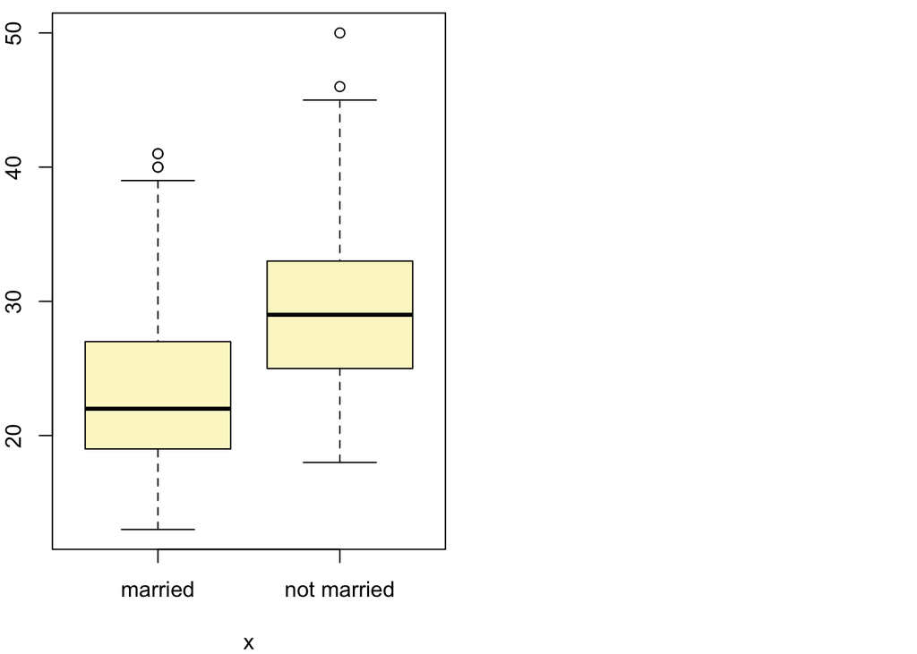

```
## Observed difference between means (married-not married) = -5.58
##
## Standard error = 0.3643
## 95 % Confidence interval = ( -6.2938 , -4.8657 )
```

There is a statistically significant difference between the mother’s age for married and non-married mothers. Married mothers tend to give birth at a younger age.

#### 6. What concepts from the textbook are covered in this lab? What concepts, if any, are not covered in the textbook? Have you seen these concepts elsewhere, e.g. lecture, discussion section, previous labs, or homework problems? Be specific in your answer.